### Red group - 1

I said that these players are the cream of the crop. We’ve already seen the stats by cluster in the anlysis above so let’s approach this a different way.

| player | name | mp | clus_5 |
| --- | --- | --- | --- |
| Ivica Zubac | pos_C | 520 | 5 |
| Kevin Durant | pos_PF | 623 | 1 |
| Kyle Lowry | pos_PG | 612 | 5 |
| OG Anunoby | pos_SF | 617 | 1 |
| Devin Booker | pos_SG | 586 | 1 |
| Jalen Green | pos_SG | 586 | 1 |
| Dejounte Murray | pos_SG | 586 | 1 |

So we can see that Red Group 1 has the most players with the top minutes played by a position. It is however interesting that there are 2 Pink group-5 members making there way onto the list. This tells me our model may not value big men enough.

Lets check in on the rebound leaders and there cluster grouping.

| player | age | g | gs | mp | fg | fga | x3p | x3pa | x2p | x2pa | ft | fta | orb | drb | ast | stl | blk | tov | pts | clus_5 | name | trb |
| --- | --- | --- | --- | --- | --- | --- | --- | --- | --- | --- | --- | --- | --- | --- | --- | --- | --- | --- | --- | --- | --- | --- |
| Clint Capela | 28 | 16 | 16 | 435 | 84 | 135 | 0 | 0 | 84 | 135 | 16 | 30 | 70 | 118 | 11 | 9 | 24 | 16 | 184 | 5 | pos_C | 188 |
| Ivica Zubac | 25 | 17 | 17 | 520 | 62 | 108 | 0 | 1 | 62 | 107 | 38 | 60 | 49 | 139 | 24 | 8 | 33 | 38 | 162 | 5 | pos_C | 188 |
| Nikola Vučević | 32 | 16 | 16 | 499 | 95 | 205 | 26 | 68 | 69 | 137 | 36 | 41 | 42 | 145 | 47 | 5 | 14 | 37 | 252 | 5 | pos_C | 187 |
| Rudy Gobert | 30 | 14 | 14 | 448 | 70 | 113 | 0 | 2 | 70 | 111 | 52 | 75 | 57 | 119 | 14 | 10 | 20 | 20 | 192 | 5 | pos_C | 176 |
| Steven Adams | 29 | 16 | 16 | 419 | 51 | 80 | 0 | 0 | 51 | 80 | 10 | 43 | 77 | 93 | 38 | 13 | 16 | 39 | 112 | 2 | pos_C | 170 |
| Bobby Portis | 27 | 15 | 5 | 407 | 83 | 179 | 19 | 58 | 64 | 121 | 20 | 25 | 40 | 124 | 31 | 7 | 3 | 15 | 205 | 5 | pos_PF | 164 |
| Domantas Sabonis | 26 | 15 | 15 | 478 | 92 | 156 | 5 | 16 | 87 | 140 | 74 | 99 | 35 | 129 | 90 | 13 | 7 | 35 | 263 | 5 | pos_PF | 164 |
| Julius Randle | 28 | 17 | 17 | 555 | 117 | 254 | 34 | 102 | 83 | 152 | 81 | 107 | 42 | 105 | 53 | 13 | 4 | 53 | 349 | 1 | pos_PF | 147 |
| Giannis Antetokounmpo | 28 | 12 | 12 | 391 | 127 | 251 | 9 | 40 | 118 | 211 | 91 | 155 | 20 | 124 | 64 | 12 | 14 | 45 | 354 | 1 | pos_PF | 144 |
| Karl-Anthony Towns | 27 | 16 | 16 | 548 | 121 | 235 | 33 | 91 | 88 | 144 | 65 | 72 | 28 | 115 | 81 | 11 | 9 | 46 | 340 | 1 | pos_PF | 143 |
| Luka Dončić | 23 | 15 | 15 | 553 | 169 | 342 | 34 | 118 | 135 | 224 | 130 | 171 | 15 | 121 | 121 | 29 | 8 | 48 | 502 | 1 | pos_PG | 136 |
| Stephen Curry | 34 | 16 | 16 | 556 | 174 | 329 | 84 | 188 | 90 | 141 | 84 | 93 | 9 | 98 | 114 | 19 | 4 | 42 | 516 | 1 | pos_PG | 107 |
| Kevin Porter Jr. | 22 | 16 | 16 | 558 | 108 | 258 | 32 | 91 | 76 | 167 | 68 | 92 | 25 | 72 | 93 | 22 | 8 | 62 | 316 | 1 | pos_PG | 97 |
| Ja Morant | 23 | 14 | 14 | 463 | 139 | 299 | 27 | 69 | 112 | 230 | 95 | 120 | 18 | 69 | 99 | 15 | 5 | 53 | 400 | 1 | pos_PG | 87 |
| Ben Simmons | 26 | 12 | 7 | 333 | 42 | 71 | 0 | 1 | 42 | 70 | 11 | 22 | 12 | 70 | 68 | 12 | 6 | 28 | 95 | 2 | pos_PG | 82 |
| Lauri Markkanen | 25 | 18 | 18 | 592 | 149 | 274 | 38 | 103 | 111 | 171 | 65 | 80 | 40 | 111 | 42 | 10 | 16 | 36 | 401 | 1 | pos_SF | 151 |
| OG Anunoby | 25 | 17 | 17 | 617 | 119 | 251 | 28 | 84 | 91 | 167 | 53 | 63 | 24 | 81 | 36 | 42 | 16 | 43 | 319 | 1 | pos_SF | 105 |
| Jaylen Brown | 26 | 15 | 15 | 538 | 143 | 292 | 34 | 101 | 109 | 191 | 59 | 72 | 15 | 88 | 52 | 16 | 6 | 50 | 379 | 1 | pos_SF | 103 |
| Paul George | 32 | 16 | 16 | 549 | 132 | 288 | 45 | 121 | 87 | 167 | 69 | 81 | 8 | 88 | 69 | 25 | 7 | 58 | 378 | 1 | pos_SF | 96 |
| Kelly Oubre Jr. | 27 | 18 | 18 | 566 | 130 | 306 | 45 | 138 | 85 | 168 | 44 | 60 | 25 | 70 | 20 | 29 | 6 | 21 | 349 | 1 | pos_SF | 95 |
| Josh Hart | 27 | 16 | 16 | 567 | 52 | 117 | 9 | 28 | 43 | 89 | 34 | 47 | 27 | 107 | 66 | 22 | 3 | 25 | 147 | 5 | pos_SG | 134 |
| Dejounte Murray | 26 | 16 | 16 | 586 | 137 | 302 | 28 | 90 | 109 | 212 | 35 | 40 | 12 | 88 | 118 | 32 | 6 | 37 | 337 | 1 | pos_SG | 100 |
| John Konchar | 26 | 16 | 8 | 434 | 49 | 104 | 27 | 65 | 22 | 39 | 7 | 8 | 24 | 75 | 25 | 16 | 5 | 9 | 132 | 2 | pos_SG | 99 |
| Anthony Edwards | 21 | 16 | 16 | 579 | 130 | 284 | 42 | 120 | 88 | 164 | 51 | 73 | 7 | 85 | 63 | 18 | 5 | 49 | 353 | 1 | pos_SG | 92 |
| Josh Giddey | 20 | 13 | 13 | 390 | 85 | 184 | 13 | 45 | 72 | 139 | 11 | 16 | 17 | 75 | 74 | 5 | 7 | 45 | 194 | 5 | pos_SG | 92 |

let’s keep looking at this one. We can filter out anyone who is not a top 5 player in at least 1 category. Lets see how this shakes out.

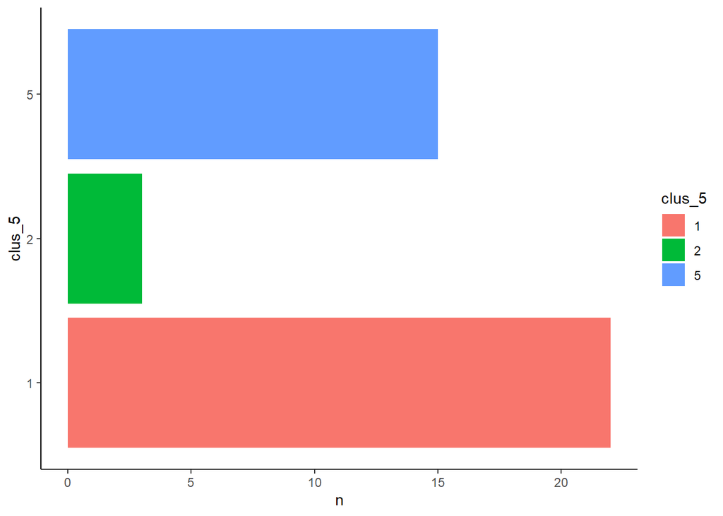

Notice that there are no group 4 people on the list.

As a reminder this is the break down of all players by cluster

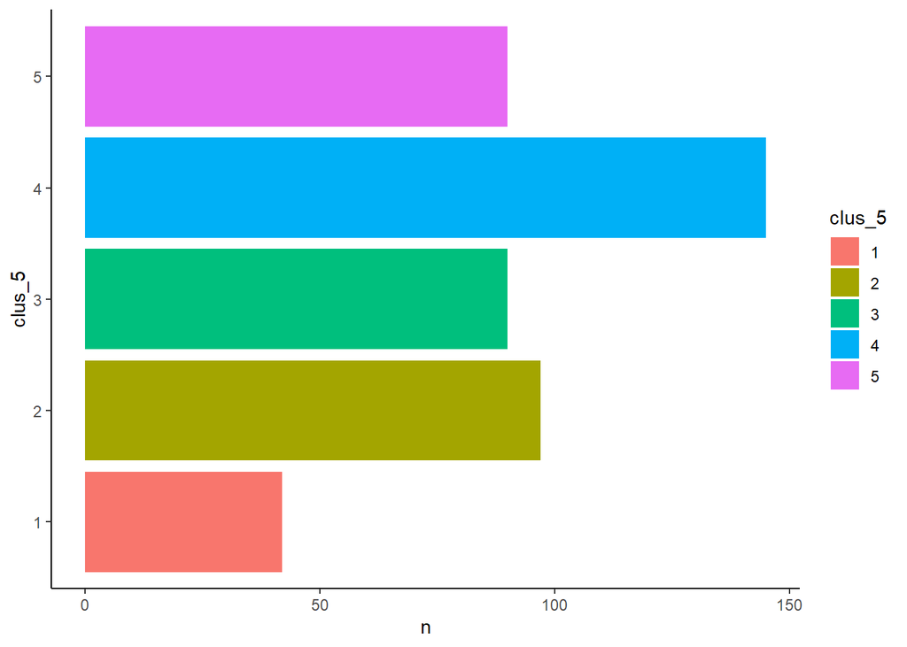

So the amount of cluster 1 folks leading the lead is telling.